# Group1

Rahul Jadhav

1/26/2022

## DATA PREPARATION

```r
library(dplyr)
main_dataset <- read.csv('Chicago_Crimes_2001_to_2017_Part2.csv')
str(main_dataset)
```

```
'data.frame':   2647095 obs. of  25 variables:
 $ X.1                 : int  4 9 10 13 15 17 19 20 29 33 ...
 $ X                   : num  2927 4564 4904 7992 9317 ...
 $ ID                  : num  4789765 4792195 4680124 4684808 4686904 ...
 $ Case.Number         : chr  "HM402058" "HM405396" "HM282389" "HM286351" ...
 $ Date                : chr  "12/30/2004 08:00:00 PM" "09/16/2004 10:00:00 AM" "01/01/2003 12:00:00 AM" "01/01/2003 12:00:00 AM" ...
 $ Block               : chr  "045XX W MONTANA ST" "003XX W HUBBARD ST" "009XX S SPAULDING AVE" "060XX S KEELER AVE" ...
 $ IUCR                : chr  "0840" "0890" "0840" "0840" ...
 $ Primary.Type        : chr  "THEFT" "THEFT" "THEFT" "THEFT" ...
 $ Description         : chr  "FINANCIAL ID THEFT: OVER $300" "FROM BUILDING" "FINANCIAL ID THEFT: OVER $300" "FINANCIAL ID THEFT: OVER $300" ...
 $ Location.Description: chr  "OTHER" "RESIDENCE" "RESIDENCE" "RESIDENCE" ...
 $ Arrest              : chr  "False" "False" "False" "False" ...
 $ Domestic            : chr  "False" "False" "False" "False" ...
 $ Beat                : int  2521 1831 1134 813 922 1422 913 1422 2514 1413 ...
 $ District            : num  25 18 11 8 9 14 9 14 25 14 ...
 $ Ward                : num  31 42 24 13 11 26 12 26 30 26 ...
 $ Community.Area      : num  20 8 29 65 59 23 59 23 19 22 ...
 $ FBI.Code            : chr  "06" "06" "06" "06" ...
 $ X.Coordinate        : num  NA NA 1154521 1149407 1165579 ...
 $ Y.Coordinate        : num  NA NA 1895755 1864157 1881889 ...
 $ Year                : int  2004 2004 2003 2003 2003 2003 2001 2002 2004 2001 ...
 $ Updated.On          : chr  "08/17/2015 03:03:40 PM" "08/17/2015 03:03:40 PM" "04/15/2016 08:55:02 AM" "04/15/2016 08:55:02 AM" ...
 $ Latitude            : num  NA NA 41.9 41.8 41.8 ...
 $ Longitude           : num  NA NA -87.7 -87.7 -87.7 ...
 $ Location            : chr  "" "" "(41.869772159, -87.708180162)" "(41.783163561, -87.727772951)" ...
 $ Parts               : chr  "Part2" "Part2" "Part2" "Part2" ...
```

```r
## check for variables with NA's and drop NA's

sapply(main_dataset, function(x) sum(is.na(x)))
```

```
                 X.1                    X                   ID
                   0                    0                    0
         Case.Number                 Date                Block
                   0                    0                    0
                IUCR         Primary.Type          Description
                   0                    0                    0
Location.Description               Arrest             Domestic
                   8                    0                    0
                Beat             District                 Ward
                   0                   32               233011
      Community.Area             FBI.Code         X.Coordinate
              233650                    0                35156
        Y.Coordinate                 Year           Updated.On
               35156                    0                    0
            Latitude            Longitude             Location
               35156                35156                 3072
               Parts
                   0
```

```r
main_dataset <- na.omit(main_dataset)

## convertion of few variables and data variable class from character to POSIXct (data-time)
main_dataset <- main_dataset %>%
  mutate(
    Arrest = ifelse(
      Arrest == "False", "FALSE",
      ifelse(
        Arrest == "True", "TRUE", main_dataset$Arrest
      )),
    Domestic = ifelse(
      Domestic == "False", "FALSE",
      ifelse(
        Domestic == "True", "TRUE", main_dataset$Domestic
      )),
    Date = as.POSIXlt(Date, format = "%m/%d/%Y %I:%M:%S %p"),
    YearOfRegistered = format(main_dataset$Date, format="%Y"),
    Month = format(main_dataset$Date, format="%m"),
    Day = format(main_dataset$Date, format="%d"),
    Time = format(main_dataset$Date, format="%I")
    )

## subsetting categorical and numerical data to perform initial analysis
num_dataset <- main_dataset[sapply(main_dataset, is.integer) | sapply(main_dataset, is.numeric) ]
character_dataset <- main_dataset[sapply(main_dataset, is.character)]
character_dataset[sapply(character_dataset, is.character)] <- lapply(
  character_dataset[sapply(
    character_dataset,
    is.character)]
  ,as.factor)
```

## SUMMARY STATISTIC

For numerical variable, we have created subset of numerical variable and categorical variable.

```r
psych::describe(num_dataset) %>%
  dplyr::select(count = n,
         Mean = mean,
         Standard_Deviation = sd,
         )%>%
  mutate(
    Coefficient_Variation = Standard_Deviation/Mean
  )
```

```
##                  count       Mean Standard_Deviation Coefficient_Variation
## X.1            2382576 8368387.14         6088845.22                  0.73
## X              2382576 2560028.67         1855327.17                  0.72
## ID             2382576 6319077.01         2290987.68                  0.36
## Beat           2382576    1194.87             703.24                  0.59
## District       2382576      11.31               6.94                  0.61
## Ward           2382576      22.61              13.79                  0.61
## Community.Area 2382576      37.74              21.57                  0.57
## X.Coordinate   2382576 1164449.87           17546.10                  0.02
## Y.Coordinate   2382576 1885420.32           33238.25                  0.02
## Year           2382576    2008.28               3.67                  0.00
## Latitude       2382576      41.84               0.09                  0.00
## Longitude      2382576     -87.67               0.06                  0.00
```

```r
summary(character_dataset)
```

```
##     Case.Number                       Block              IUCR
##  G183906  :      3   100XX W OHARE ST    :   5572   0486   : 201151
##  HS496074 :      3   001XX N STATE ST    :   3815   0820   : 172674
##  07C115980:      2   076XX S CICERO AVE  :   3628   0460   : 157801
##  F746059  :      2   008XX N MICHIGAN AVE:   3112   1320   : 129938
##  G011117  :      2   0000X N STATE ST    :   2836   1310   : 125115
##  G021349  :      2   023XX S STATE ST    :   2223   0810   : 120732
##  (Other)  :2382562   (Other)             :2361390   (Other):1475165
##           Primary.Type                     Description
##  THEFT          :493087   SIMPLE                 : 258195
##  BATTERY        :432498   DOMESTIC BATTERY SIMPLE: 201151
##  CRIMINAL DAMAGE:277627   $500 AND UNDER         : 172671
##  NARCOTICS      :265828   TO VEHICLE             : 133755
##  OTHER OFFENSE  :147228   TO PROPERTY            : 125115
##  ASSAULT        :143936   OVER $500              : 120729
##  (Other)        :622372   (Other)                :1370960
##                      Location.Description   Arrest         Domestic
##  STREET                        :622288    FALSE:1709327   FALSE:2074846
##  RESIDENCE                     :393289    TRUE : 673249   TRUE : 307730
##  SIDEWALK                      :256070
##  APARTMENT                     :253877
##  OTHER                         : 85787
##  PARKING LOT/GARAGE(NON.RESID.): 66602
##  (Other)                       :704663
##     FBI.Code                       Updated.On
##  06     :493087   02/04/2016 06:33:39 AM:1187279
##  08B    :371518   04/15/2016 08:55:02 AM:1020911
##  14     :277627   08/17/2015 03:03:40 PM:  53417
##  18     :249063   04/15/2016 03:49:27 PM:   2629
##  26     :245182   09/10/2015 11:43:14 AM:   2113
##  05     :143838   10/09/2015 03:58:54 PM:   2051
##  (Other):602261   (Other)               : 114176
##                           Location         Parts
##  (41.976290414, -87.905227221):   5569   Part2:2382576
##  (41.754592961, -87.741528537):   3606
##  (41.883500187, -87.627876698):   2426
##  (41.897895128, -87.624096605):   1567
##  (41.909664252, -87.742728815):   1290
##  (41.885487535, -87.726422045):   1207
##  (Other)                      :2366911
##                YearOfRegistered                      Month
##  01/01/2008 12:01:00 AM:    116   01/01/2008 12:01:00 AM:    116
##  01/01/2008 12:00:00 AM:     84   01/01/2008 12:00:00 AM:     84
##  01/01/2009 12:01:00 AM:     79   01/01/2009 12:01:00 AM:     79
##  01/01/2007 12:01:00 AM:     73   01/01/2007 12:01:00 AM:     73
##  01/01/2007 12:00:00 AM:     71   01/01/2007 12:00:00 AM:     71
##  01/01/2009 12:00:00 AM:     70   01/01/2009 12:00:00 AM:     70
##  (Other)               :2382083   (Other)               :2382083
##                      Day                              Time
##  01/01/2008 12:01:00 AM:    116   01/01/2008 12:01:00 AM:    116
##  01/01/2008 12:00:00 AM:     84   01/01/2008 12:00:00 AM:     84
##  01/01/2009 12:01:00 AM:     79   01/01/2009 12:01:00 AM:     79
##  01/01/2007 12:01:00 AM:     73   01/01/2007 12:01:00 AM:     73
##  01/01/2007 12:00:00 AM:     71   01/01/2007 12:00:00 AM:     71
##  01/01/2009 12:00:00 AM:     70   01/01/2009 12:00:00 AM:     70
##  (Other)               :2382083   (Other)               :2382083
```

## BASIC ANALYSIS

### Primary type of crimes

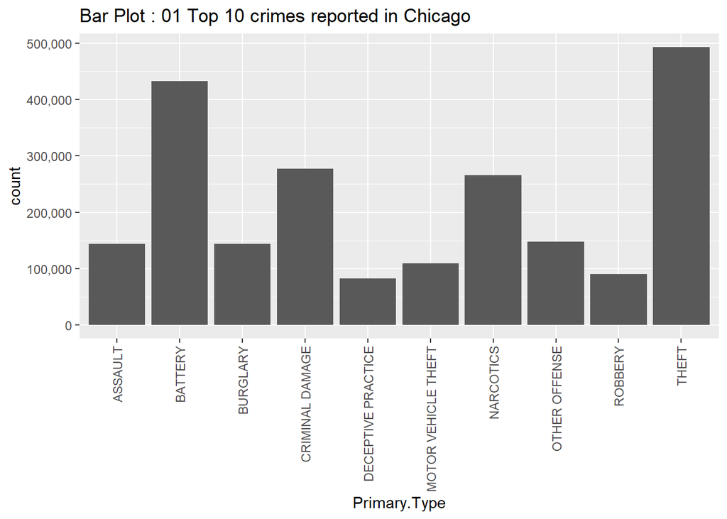

```r
library(dplyr)
library(ggplot2)
group_by_primary_type <- main_dataset %>%
  group_by(Primary.Type) %>%
  summarise(count = n())%>%
  mutate(
    porportion = round(count/sum(count),2),
    percentage = round((count/sum(count)*100),2)
  ) %>%
  arrange(desc(percentage)) %>%
  head(10)


ggplot(group_by_primary_type,aes(x=Primary.Type,y=count))+
  geom_bar(position="dodge", stat="identity")+
  theme(axis.text.x = element_text(angle = 90, vjust = 0.5, hjust=1))+
  scale_y_continuous(label = comma)+
  ggtitle("Bar Plot : 01 Top 10 crimes reported in Chicago")
```

```r
group_by_primary_type <- main_dataset %>%
  group_by(Primary.Type,Arrest) %>%
  summarise(count = n())%>%
  mutate(
    porportion = round(count/sum(count),2),
    percentage = round((count/sum(count)*100),2)
  ) %>%
  arrange(desc(percentage))
```

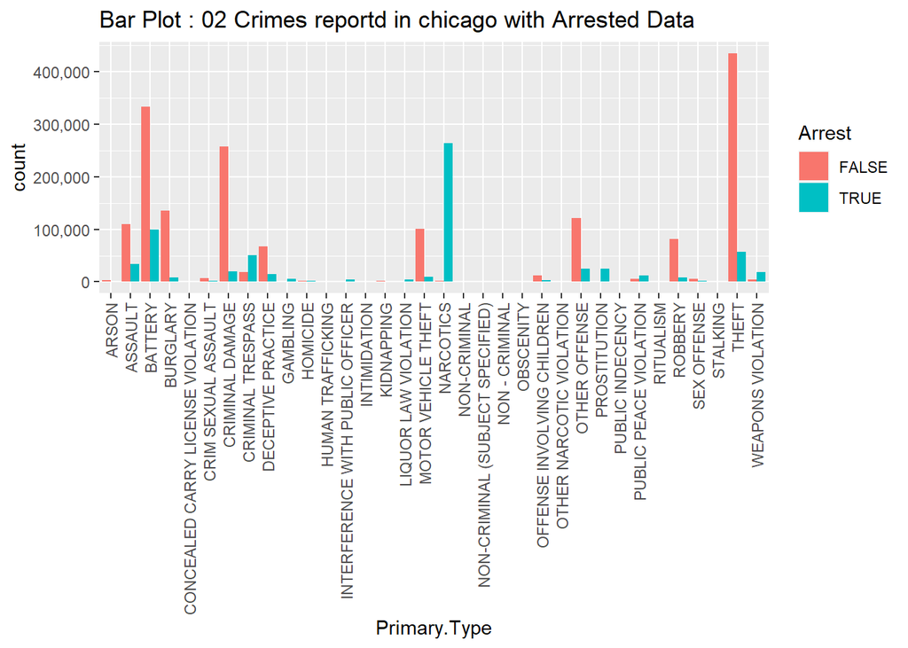

```r
ggplot(group_by_primary_type,aes(x=Primary.Type,y=count,fill= Arrest))+
  geom_bar(position="dodge", stat="identity")+
  theme(axis.text.x = element_text(angle = 90, vjust = 0.5, hjust=1))+
  scale_y_continuous(label = comma)+
  ggtitle("Bar Plot : 02 Crimes reportd in chicago with Arrested Data")
```

From the above plot you can see that from the from the amount of cases registered, the arrests are less. Among all the aother primary type of crimes , Theft cases are reported at the highest followed by battery and criminal damage.

### Year-Wise Crime rate

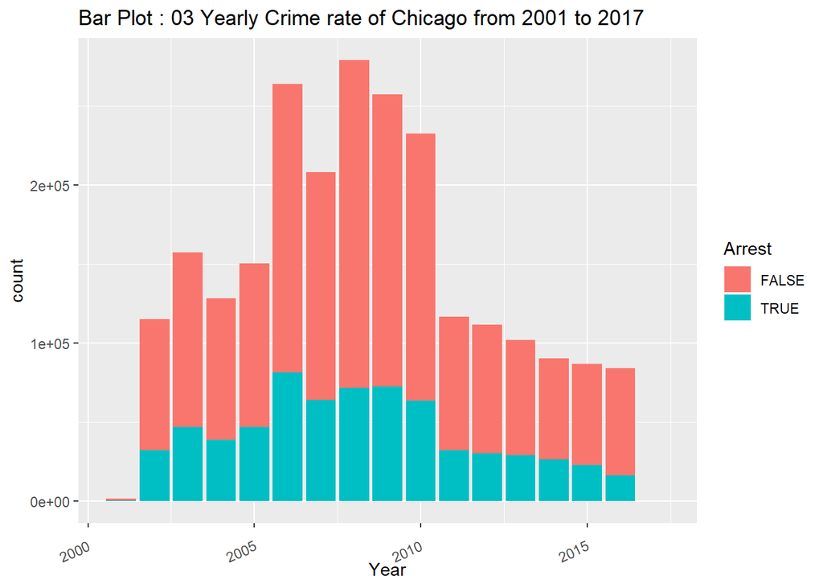

```r
library(dplyr)
library(ggplot2)
group_by_Year <- main_dataset %>%
  group_by(Year,Arrest) %>%
  summarise(count = n()) %>%
  mutate(
    porportion = round(count/sum(count),2),
    percentage = round((count/sum(count)*100),2)
  ) %>%
  arrange((Year))
ggplot(group_by_Year,aes(x=Year,y=count, fill= Arrest))+
  geom_bar(stat="identity")+
  theme(axis.text.x = element_text(angle = 25, vjust = 0.5, hjust=1))+
  ggtitle("Bar Plot : 03 Yearly Crime rate of Chicago from 2001 to 2017")
```

From the above plot you can see that between the year 2006 to 2010, the crime reported where highest. After 2010 we can see the down trend in the crime rates

### ARREST

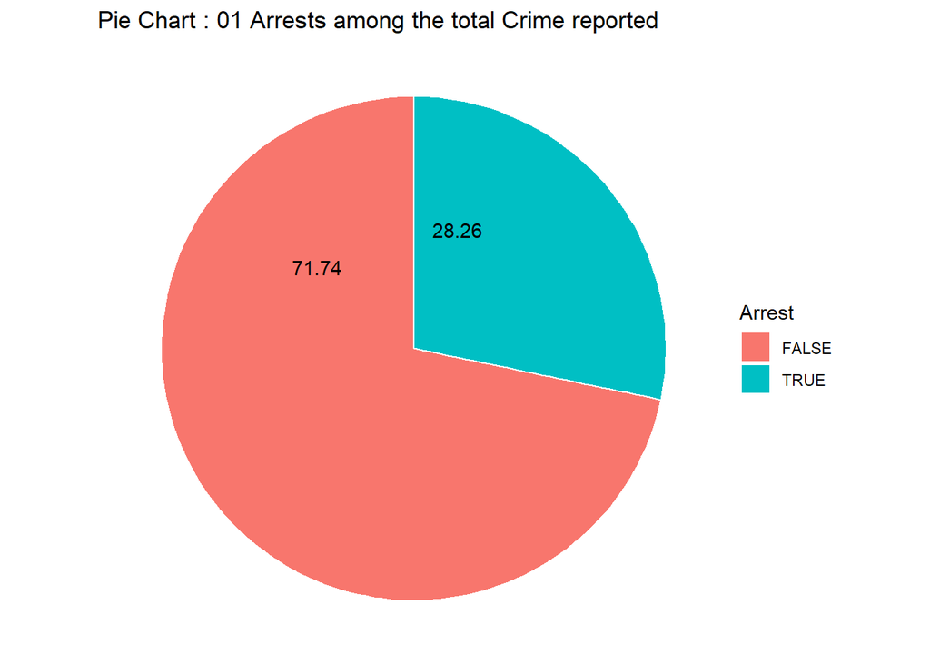

```r
group_by_Arrest <- main_dataset %>%
  group_by(Arrest)  %>%
  summarise(count = n()) %>%
  mutate(
    porportion = round(count/sum(count),2),
    percentage = round((count/sum(count)*100),2)
  ) %>%
  mutate(ypos = cumsum(percentage)+ 0.2*percentage )
ggplot(group_by_Arrest, aes(x="", y=percentage, fill=Arrest)) +
  geom_bar(stat="identity", width=1, color="white") +
  coord_polar("y", start=0) +
  theme(legend.position="none") +
  theme_void()+
  ggtitle("Pie chart of Arrest")+
  geom_text(y = group_by_Arrest$ypos,label=group_by_Arrest$percentage)+
  ggtitle("Pie Chart : 01 Arrests among the total Crime reported")
```

From the above plot you can see that about 71.74% of the crime reported had no arrests where as 28.26% of the crime reported have arrests.

```r
group_by_District <- main_dataset %>%
  group_by(District,Arrest) %>%
  summarise(count = n()) %>%
  mutate(
    porportion = round(count/sum(count),2),
    percentage = round((count/sum(count)*100),2)
  )
```

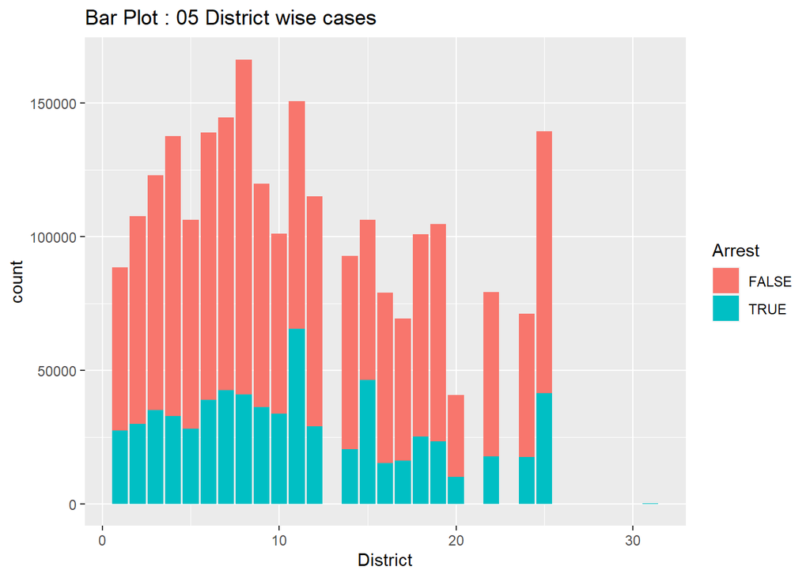

```r
ggplot(group_by_District,aes(x=District,y=count, fill= Arrest))+
  geom_bar(stat="identity")+
  ggtitle("Bar Plot : 05 District wise cases")+
  xlab("District")
```

## CORRELATION

Checking correlation between District crime primary type and arrests

```r
## from our eda we will concentrate on 9 primary type criminal cases and merge remaining to other primary type
primary_Type <- main_dataset %>%
  mutate(
    Primary.Type = ifelse(
      Primary.Type == "THEFT" , "THEFT",
      ifelse(
        Primary.Type == "BATTERY", "BATTERY",
        ifelse(
          Primary.Type == "CRIMINAL DAMAGE", "CRIMINAL DAMAGE   ",
          ifelse(
            Primary.Type == "NARCOTICS", "NARCOTICS",
            ifelse(
              Primary.Type == "ASSAULT", "ASSAULT",
              ifelse(
                Primary.Type == "BURGLARY", "BURGLARY",
                ifelse(
                  Primary.Type == "MOTOR VEHICLE THEFT", "MOTOR VEHICLE THEFT",
                  ifelse(
                    Primary.Type == "ROBBERY", "ROBBERY",
                    ifelse(
                      Primary.Type == "DECEPTIVE PRACTICE", "DECEPTIVE PRACTICE", "OTHER OFFENCES"
                    )
                  )
                )
              )
            )
          )
        )
      )
    )
  )

primary_Type <- primary_Type %>%
  select(Primary.Type,District,Arrest)
primary_type <- dummy_cols(primary_Type)


primary_type <- primary_type[-c(1,3)]
names(primary_type) <- c('District', 'ASSAULT', 'BATTERY', 'BURGLARY', 'CRIMINAL DAMAGE', 'DECEPTIVE PRACTICE','MOTOR VEHICLE THEFT', 'NARCOTICS', 'OTHER OFFENCES', 'ROBBERY', 'THEFT', 'NOT.Arrested', 'Arrested')
class(primary_type$Primary.Type)
```

```
## [1] "NULL"
```

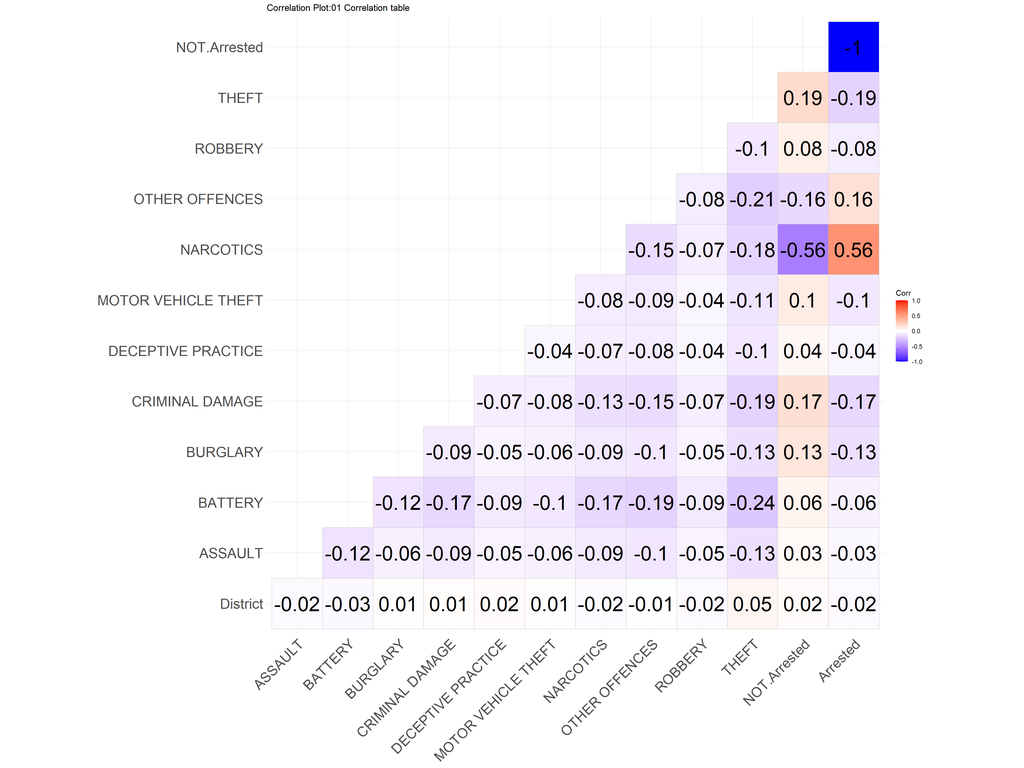

```r
ggcorrplot::ggcorrplot(cor(primary_type),
                       lab_size = 10,
                       tl.cex = 20,
                       title = "Correlation Plot:01 Correlation table"
                       ,type = "lower",
                       lab = TRUE)
```

## CHI-SQUARE ANALYSIS

H0 (null hypothesis) -> There is no relationship between District and Primary type of Crime H1 (Alternative Hypothesis) -> There is relationship between District and Primary type of Crime

```r
chi <- main_dataset
myChisq <- xtabs(~ as.factor(Primary.Type) + as.factor(District), data = chi)

tidy(chisq.test(myChisq))%>%
  select(
    method,
    DF = parameter,
    p.value,
    statistic
  )%>%
  mutate(
    statistic = round(statistic,2)
  )
```

```
## # A tibble: 1 x 4
##   method                        DF p.value statistic
##   <chr>                      <int>   <dbl>     <dbl>
## 1 Pearson's Chi-squared test   792       0   297892.
```

Since the p.value is very significant, we will reject the null hypothesis.

## 2 WAY ANOVA TEST

Performing ANOVA test to examine if District varies by Primary type of crime and Arrests.

H0(null hypothesis) -> * Primary type of crime and Arrest has no effect on District. Also there is no interaction affect on District due to Primary type of crime and Arrests.

H1(Alternative Hypothesis) -> * Primary type of crime and Arrest has effect on District. Also there is interaction affect on District due to Primary type of crime and Arrests.

```r
two_way_fit <- aov(District ~as.factor(Primary.Type) * as.factor(Arrest) , data=main_dataset)
tidy(two_way_fit)%>%
  mutate(
    sumsq = signif(sumsq, digits = 2),
    p.value = round(p.value,3),
    statistic = round(statistic,3)

  )
```

```
## # A tibble: 4 x 6
##   term                                     df     sumsq meansq statistic p.value
##   <chr>                                 <dbl>     <dbl>  <dbl>     <dbl>   <dbl>
## 1 as.factor(Primary.Type)                  33    640000 1.93e4     403.        0
## 2 as.factor(Arrest)                         1      2100 2.06e3      43.1       0
## 3 as.factor(Primary.Type):as.factor(~      30     87000 2.90e3      60.7       0
## 4 Residuals                           2382511 110000000 4.78e1      NA        NA
```

Interpretation : A two-way ANOVA was performed to analyze the effect of Primary type of crime and Arrest on District. A two-way ANOVA revealed that - Simple main effects analysis showed that Primary type of crime did have a statistically significant effect on District (p = 0).

## INTERACTION PLOT FROM ANOVA

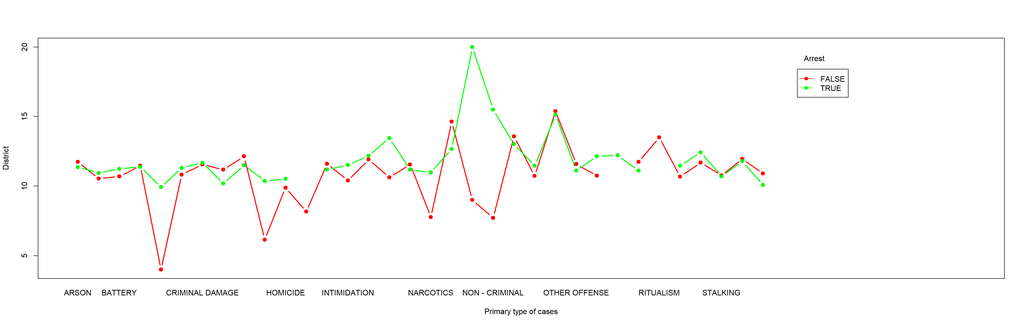

```r
## merging Exterior values lesser than 60
test <- main_dataset
interaction.plot(x.factor = main_dataset$Primary.Type,
                 trace.factor = main_dataset$Arrest,
                 response = main_dataset$District,
                 fun = mean,
                 type = "b",
                 ylab = "District",
                 xlab = "Primary type of cases",
                 col = c("red","green"),
                 lty = 1, #line type
                 lwd = 2, #line width
                 trace.label = "Arrest",
                 pch=c(19),             ### Symbols for levels of trace var.
                 fixed=TRUE,                    ### Order by factor order in data
                 leg.bty = "o")
```

## CONCLUSION

<> There is a decline trend in crimes after the year 2010.

<> From the cases reported only in 28.26% of the cases arrests are been carried out.

<> From chi square test we can see that there is a dependency of crime with district.

<> From anova test we can say that Primary type of crime and Arrest has effect on District. Also there is interaction affect on District due to Primary type of crime and Arrests